# Problem 1 – Solder skips

Part A

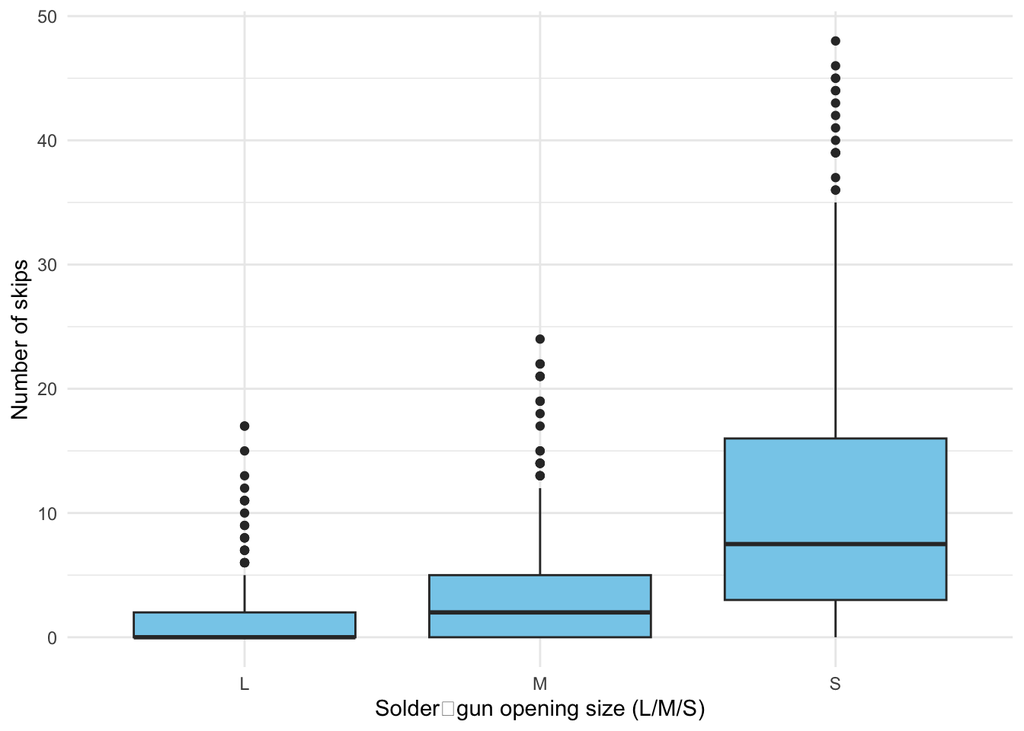

```r
ggplot(solder, aes(Opening, skips)) +
  geom_boxplot(fill="skyblue") +
  labs(
    x = "Solder‑gun opening size (L/M/S)",
    y = "Number of skips"
  ) +
  theme_minimal()
```

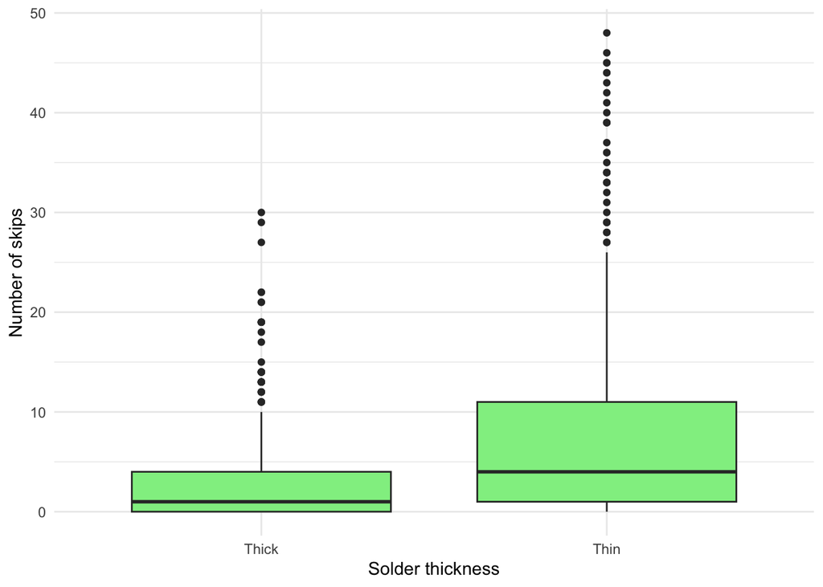

```r
ggplot(solder, aes(Solder, skips)) +
  geom_boxplot(fill="lightgreen") +
  labs(
    x = "Solder thickness",
    y = "Number of skips"
  ) +
  theme_minimal()
```

Part B: Fit model and tabulate coefficients + 95% CIs

```r
model <- lm(skips ~ Opening * Solder, data = solder)

coef_table <- tidy(model, conf.int = TRUE) %>%
  select(term, estimate, conf.low, conf.high) %>%
  mutate_if(is.numeric, ~ round(., 3))

kable(
  coef_table,
  col.names = c("Coefficient", "Estimate", "95% CI Lower", "95% CI Upper"),
  caption = "Table 1: Model estimates and 95% CIs for skips ~ Opening * Solder"
)
```

Table 1: Model estimates and 95% CIs for skips ~ Opening * Solder

| Coefficient | Estimate | 95% CI Lower | 95% CI Upper |
| --- | --- | --- | --- |
| (Intercept) | 0.393 | -0.628 | 1.415 |
| OpeningM | 2.407 | 0.962 | 3.851 |
| OpeningS | 5.127 | 3.682 | 6.571 |
| SolderThin | 2.280 | 0.836 | 3.724 |
| OpeningM:SolderThin | -0.740 | -2.782 | 1.302 |
| OpeningS:SolderThin | 9.653 | 7.611 | 11.696 |

Part C: What the coefficients tell me

Intercept (Large opening & thick solder): This is our “starting point.” With a large opening and thick solder, the model predicts about 0.39 skips on average (95% CI: –0.63 to 1.42). In other words, almost no defects under those conditions.

Opening = M (Medium vs. large, thick solder): If we shrink the opening from large to medium (still using thick solder), skips go up by about 2.41 (95% CI: 0.96 to 3.85). So medium openings lead to noticeably more flaws.

Opening = S (Small vs. large, thick solder): Dropping to a small opening (with thick solder) adds around 5.13 skips (95% CI: 3.68 to 6.57). That’s more than twice the extra skips compared to just going to medium!

Solder = Thin (Thin vs. thick, large opening): Keeping the opening large but switching to thin solder costs us about 2.28 extra skips (95% CI: 0.84 to 3.72). Thin alloy by itself definitely makes things worse.

Medium×Thin interaction: When we combine medium opening and thin solder, the model actually shows 0.74 fewer skips than you’d expect if you just added their individual effects—but the 95% CI (–2.78 to 1.30) includes zero, so we can’t be sure it’s a real effect.

Small×Thin interaction: Putting a small opening together with thin solder is a terrible combo: about 9.65 extra skips beyond what you’d predict from each factor alone (95% CI: 7.61 to 11.70). That interaction is really big and clearly significant.

Part D: What I’d recommend Everything points to the same conclusion: the large opening with thick solder gives the fewest skips (around 0.39). Any move toward a smaller opening or thinner solder increases flaws, especially if you do both. So to keep defects as low as possible, I’d choose large opening + thick solder every time.